# Data Speaks Happiness

Yu Shen

2/4/2019

```
## [1] 32911 35862 38809
```

# Introduction

**Happiness** is the most debated topic for humankind. with the pressure coming from the study and work. Being happy has become one goal in our daily life. The research for happiness is inevitably an meaningful task for us. Happy moment can be different amoong people from different ages, genders, races and relationship status.So, what what make these people happy? Is happiness embodied in physical activity or emotional sentiments? Does youth define happiness from different angles? Do women feel different from men and other genders when it comes to their happy moments? etc.

In this paper, I explored the HappyDB data with more than 100,000 crowd-sourced happy moments.

```r
#basic data statistics and distribution
age_stat <- summary(mydata$age)
## define people with age under 30 is young and above 30 is old
young_num <- length(which(mydata$age <= 30))
old_num <- length(which(mydata$age > 30))
data.frame(young_num,old_num)
```

| young_num | old_num |
| --- | --- |
| 53508 | 46355 |

```r
male_num <- length(which(mydata$gender=="m"))
female_num <- length(which(mydata$gender=="f"))
male_num/length(mydata$gender)
```

```
## [1] 0.5742467
```

```r
female_num/length(mydata$gender)
```

```
## [1] 0.4188038
```

```r
single_num <- length(which(mydata$marital=="single"))
married_num <- length(which(mydata$marital=="married"))
divorced_num <- length(which(mydata$marital=="divorced"))

single_num/length(mydata$marital)
```

```
## [1] 0.5387681
```

```r
married_num/length(mydata$marital)
```

```
## [1] 0.4121747
```

```r
divorced_num/length(mydata$marital)
```

```
## [1] 0.03780179
```

The average age is 32 years old with the youngest ones being 17 years old and the oldest being 98 years old. Around 57% are men and 42% are women. Approximately 54% are single, 41% are married, roughly 4% are divorced and the remaining 1% are either separated or widowed.

## Data Exploration

In all of the provided data , let’s look at how these categories of happiness are distributed:

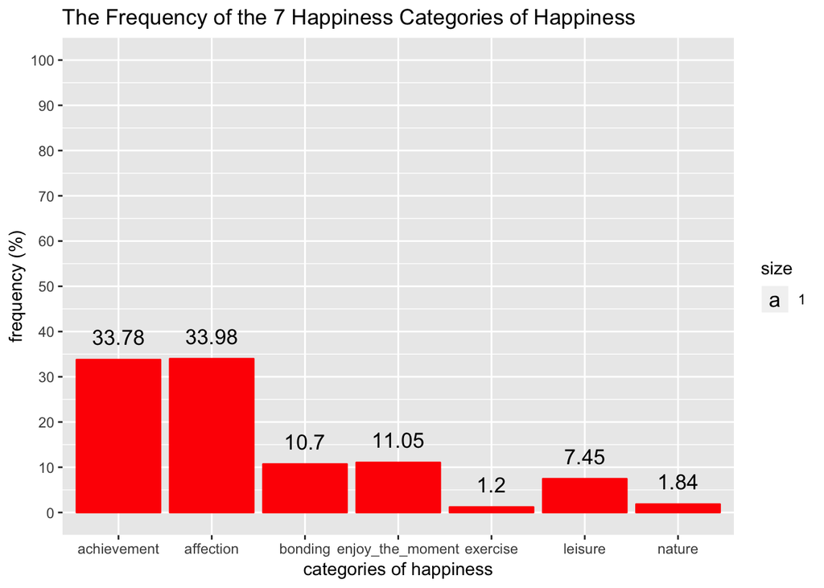

This sample gives an 7 categories of happiness:

1. Achievement
2. Affection
3. Bonding
4. Enjoying the Moment
5. Exercise
6. Leisure
7. Nature

From this graph, it looks like people’s happiness concentrates significantly around themes of achievement and affection. Enjoying the moment and bonding come 3rd and 4th in rank, respectively. Then, Leisure, nature and exercise come 5th, 6th and 7th in rank.

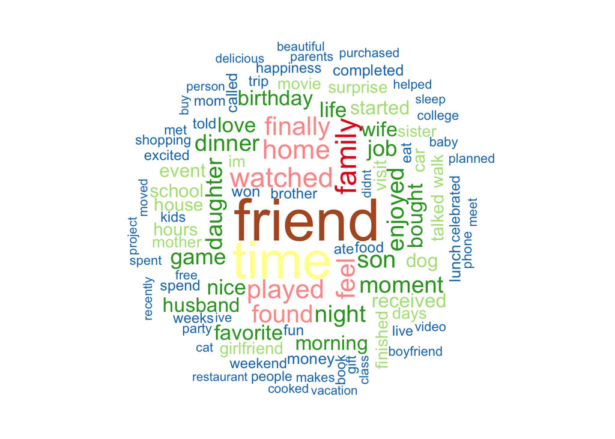

These are the most frequently used words to describe lived happy moments. Friend, Time and Family are the top 3 words they use to describe hapiness

Now let’s look closer at other information that we have, such as age, gender and relationship status. These variables could tell us different stories about the distribution of these happy moments. Accordingly, I will look further into studying genders, young and old people, marital situations, and parenthood.

## 1. Age:

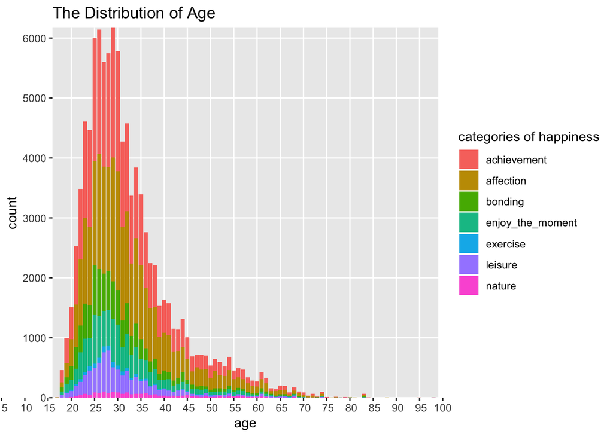

1. Younger than 20 years old: early adult
2. 20-40 years old: young adults
3. 41-65 years old: adults
4. Older than 65 years od: seniors

So let’s see how much of importance does each of the happiness categories have in the lives of our aformentioned age groups:

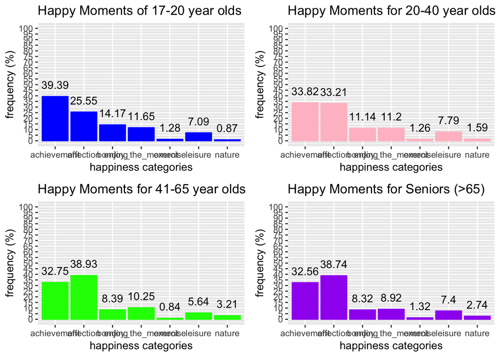

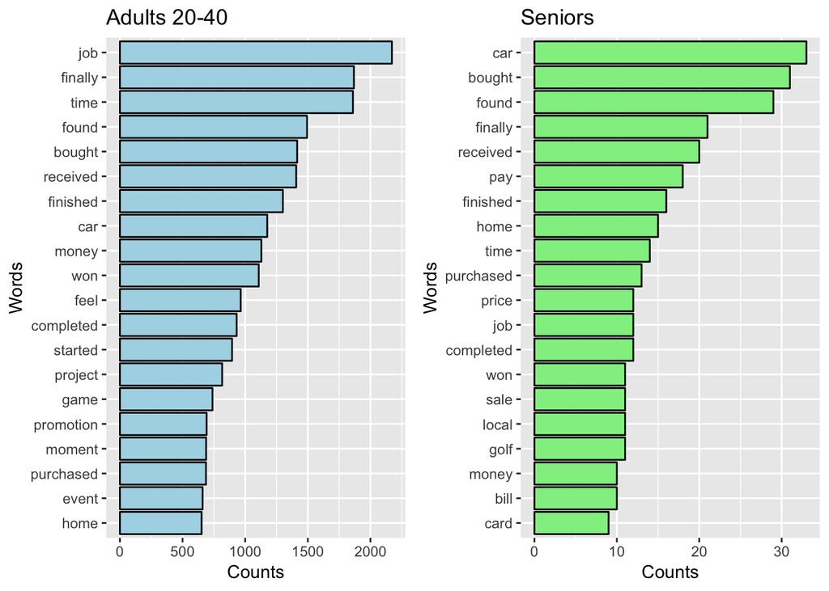

We can see that the happiness stemming from accomplishment for adults between 20 and 40 years old is related to job, money and promotion. Seniors have almost the similar but also different frequent words; evidently the concerns of the two age groups is different given they’re at different life stages. Senior care more about life quility such as cars and jobs is not as so important for them as young people Next Step is analyze genders and see if one has a different say from the other as regards moments of happiness.

## 2. Gender:

In this regard, I will study the two prominent genders in the data: female and male (I will use women and men as labels)

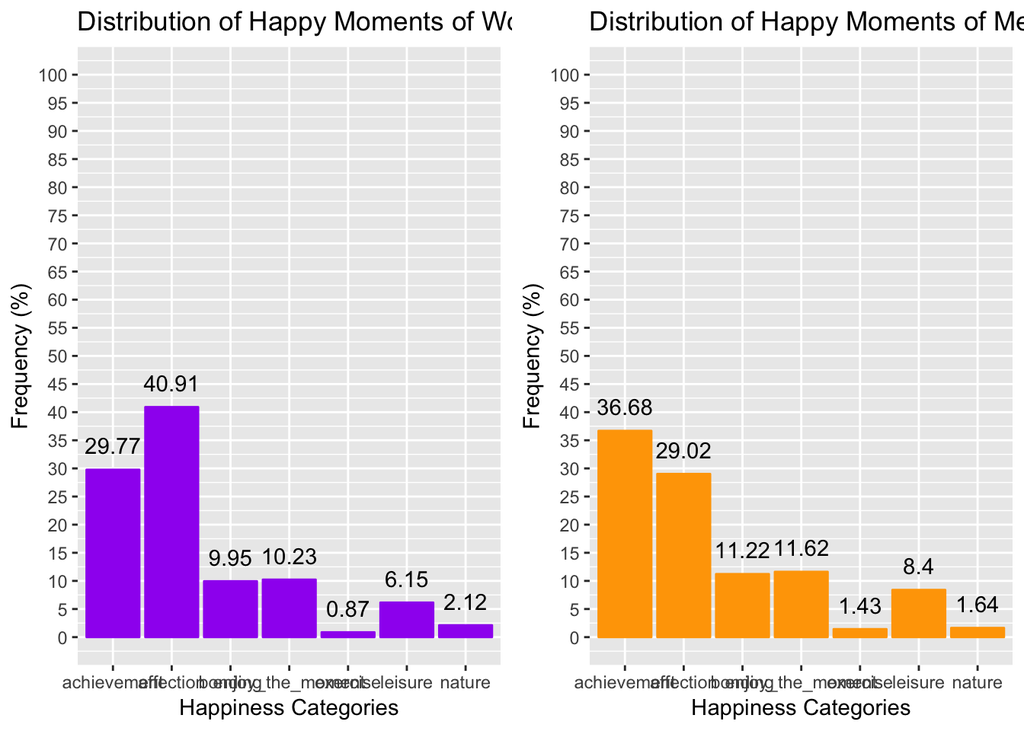

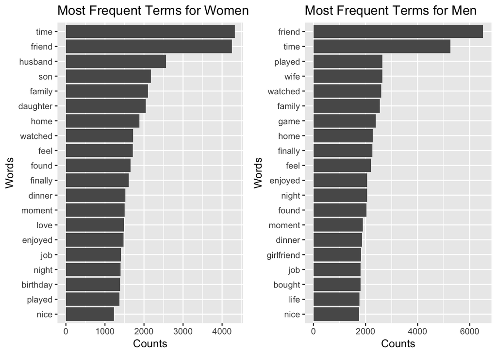

The previously demonstrated disparities suggest that men and women have their own relative perspective of happiness. Men are driven by accomplishments more than affection, as opposed to women. Next,let’s explore the marital status of the individuals in our data.

## 3. Marital Status:

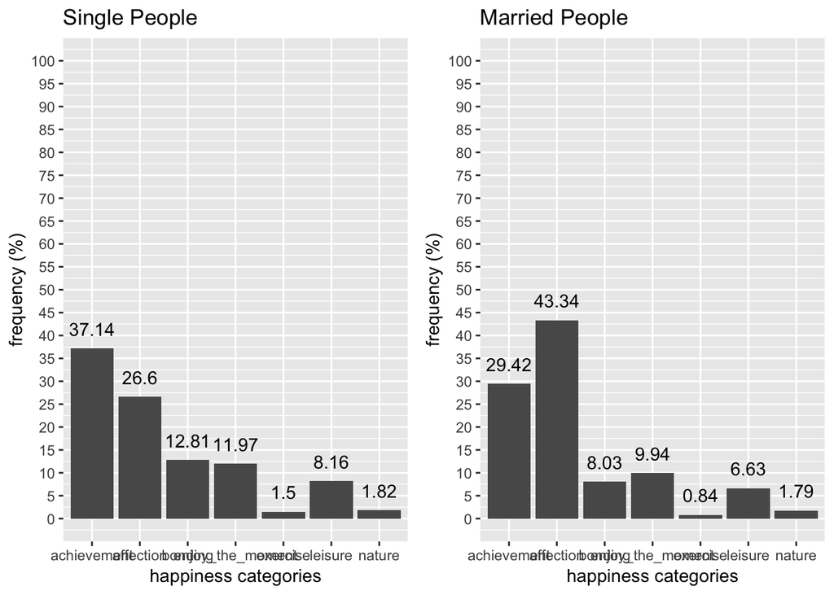

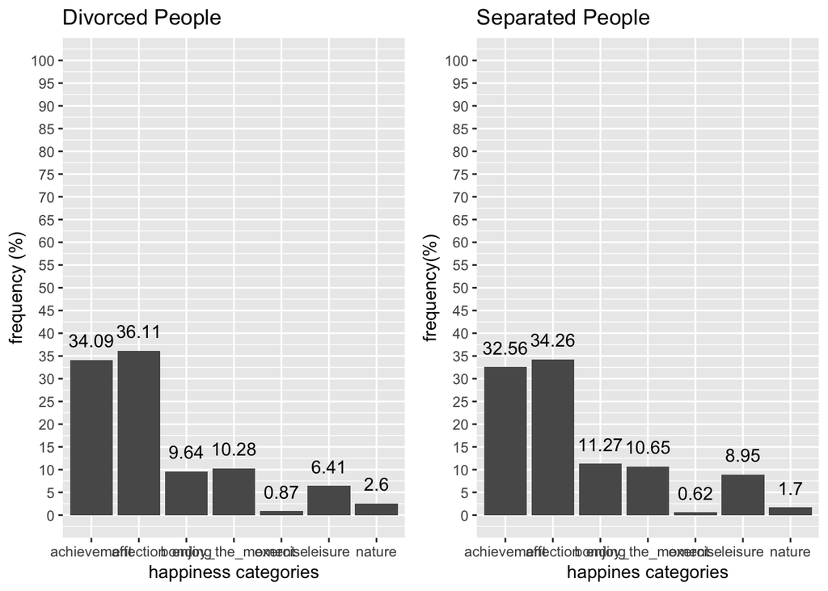

Achievement is more important for single people than for married people. Overall, affection and achievement followed by bonding and living the moment seem to define people’s happiness. Now, I will consider a combination of factors: age, gender, marital status, and parenthood.

## 4. Personas:

Let’s consider two different profiles for both women and men: the profiles are of same age but one is single with no children and the other is married. I would like to see if marital status and having children has any impact in altering one’s perspective of happiness.

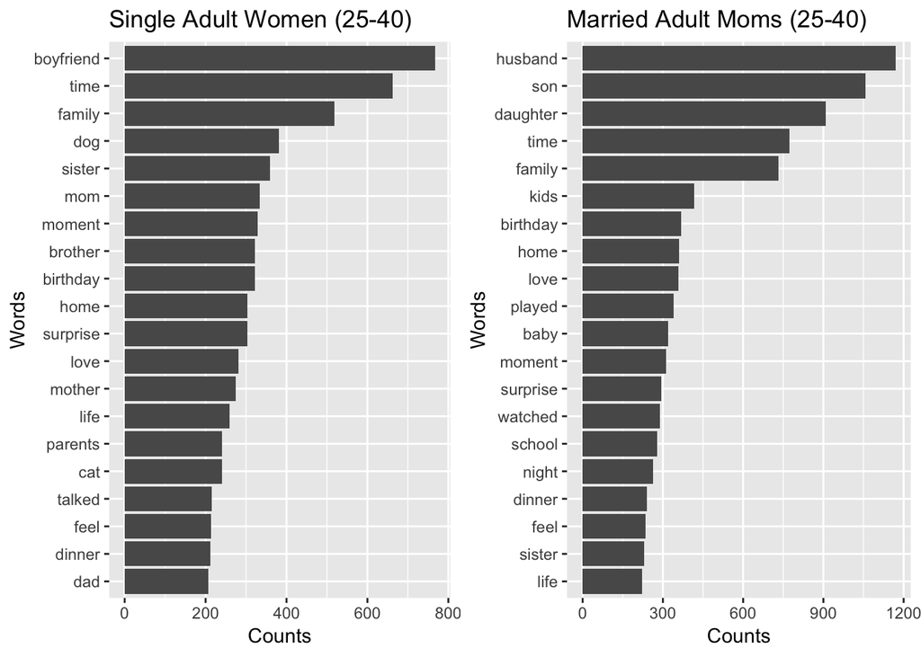

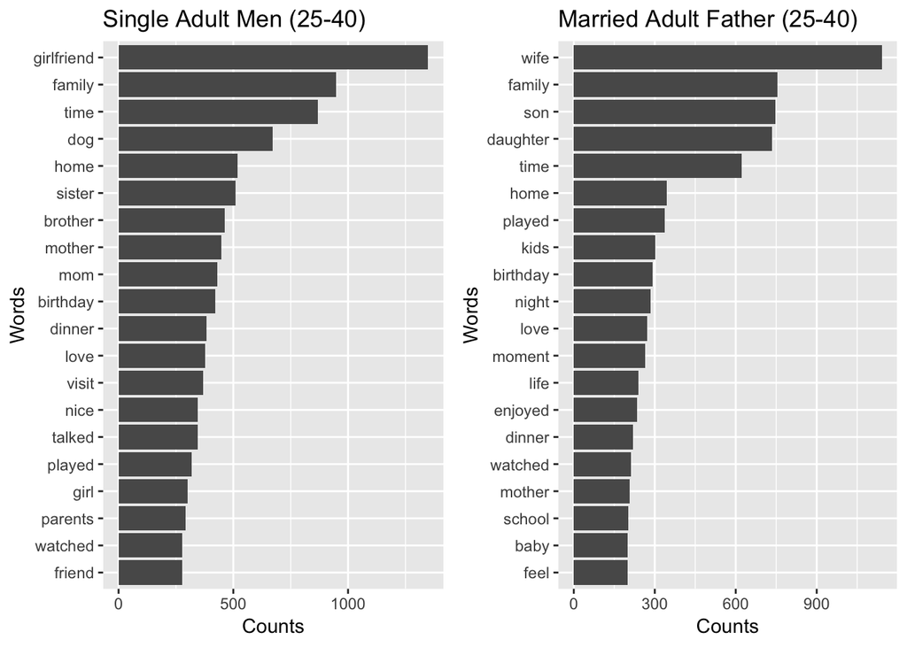

It is interesting to see how children and the husband represent a big part of a married mother’s happy affection moments. On the other hand, single adult women’s happiness are dominantly defined by their boyfriend, family and pets. The same applies for the comparison between single adult men and married adult fathers, i.e gender does not make much difference in this situation.

**Summary** As you grow in age, your definition of happiness change. Children are a source of joy to mothers same as fathers. Affection is the highlight of married adult individuals. And if you are a single adult woman or man, you’re most likely going to find your happiness in your achievement, but you will also find it in affection and essentially with a significant other or family. Ultimately, gender does not alter the perception of happiness necessarily, as we’ve seen both men and women define their happiness almost similarly under similar life situations.

**References** 1. https://github.com/rit-public/HappyDB